# html template

for IA_plots package

Eviatar

Last updated: 13-02-2023

```r
# note the chunk options:
# 1. its name is "setup". setup has to be the first chunk in the document, were global settings are defined.
# 2. "include = FALSE" means this chunk won't be seen in the html document.


# default chuck options for the entire document.
# one can overwrite these locally in the chunk options or set them globally as done here:
knitr::opts_chunk$set(echo = TRUE,
                      warning = FALSE,
                      message = FALSE,
                      tidy = FALSE,
                      fig.width = 10,
                      fig.height = 7,
                      fig.path='Figures_RMD/',
                      fig.align = 'center')

# Do not display NA's in printed tables, instead use a blank space
options(knitr.kable.NA = '')
```

# Intro

כיוון ש RStudio לא תומכת בכתיבה מימין לשמאל, כדאי לכתוב את הדברים שרוצים בעברית בקובץ וורד נפרד ואז לעתיק לתוך קובץ ה Rmd

# 1 Setup

- **load packages and more…**  
  The next code chunk does several things:
  1. `pacman` loads called packages and installs missing packages.
  2. setting defaults in R: turning off scientific notation and limit the amount of decimal digits after the “.”
  3. sets up the IA_theme for ggplot

If you use more functions in the document, its a good place to define them here.

```r
# load packages:
pacman::p_load('tidyverse', 'magrittr', 'kableExtra','stargazer', 'here', 'IAplots')

# turn off scientific notation and print 3 decimal digits.
options(scipen = 999,digits = 3)

# set ggplot theme
theme_set(IA_theme())
```

# 2 print data

**inline print of r code**  
You can embed one row result inline. `` `r `` `your code here` ` .  
for instance: The number of observations in the mtcars data is 32

**4 ways to present a table**

1. default

```r
head(mtcars)
```

```
##                    mpg cyl disp  hp drat   wt qsec vs am gear carb
## Mazda RX4         21.0   6  160 110 3.90 2.62 16.5  0  1    4    4
## Mazda RX4 Wag     21.0   6  160 110 3.90 2.88 17.0  0  1    4    4
## Datsun 710        22.8   4  108  93 3.85 2.32 18.6  1  1    4    1
## Hornet 4 Drive    21.4   6  258 110 3.08 3.21 19.4  1  0    3    1
## Hornet Sportabout 18.7   8  360 175 3.15 3.44 17.0  0  0    3    2
## Valiant           18.1   6  225 105 2.76 3.46 20.2  1  0    3    1
```

2. IA_t1

```r
head(mtcars) %>% IA_t1()
```

|  | mpg | cyl | disp | hp | drat | wt | qsec | vs | am | gear | carb |
| --- | --- | --- | --- | --- | --- | --- | --- | --- | --- | --- | --- |
| Mazda RX4 | 21.0 | 6 | 160 | 110 | 3.90 | 2.62 | 16.5 | 0 | 1 | 4 | 4 |
| Mazda RX4 Wag | 21.0 | 6 | 160 | 110 | 3.90 | 2.88 | 17.0 | 0 | 1 | 4 | 4 |
| Datsun 710 | 22.8 | 4 | 108 | 93 | 3.85 | 2.32 | 18.6 | 1 | 1 | 4 | 1 |
| Hornet 4 Drive | 21.4 | 6 | 258 | 110 | 3.08 | 3.21 | 19.4 | 1 | 0 | 3 | 1 |
| Hornet Sportabout | 18.7 | 8 | 360 | 175 | 3.15 | 3.44 | 17.0 | 0 | 0 | 3 | 2 |
| Valiant | 18.1 | 6 | 225 | 105 | 2.76 | 3.46 | 20.2 | 1 | 0 | 3 | 1 |

3. IA_t2

```r
mtcars %>% IA_t2(600)
```

|  | mpg | cyl | disp | hp | drat | wt | qsec | vs | am | gear | carb |
| --- | --- | --- | --- | --- | --- | --- | --- | --- | --- | --- | --- |
| Mazda RX4 | 21.0 | 6 | 160.0 | 110 | 3.90 | 2.62 | 16.5 | 0 | 1 | 4 | 4 |
| Mazda RX4 Wag | 21.0 | 6 | 160.0 | 110 | 3.90 | 2.88 | 17.0 | 0 | 1 | 4 | 4 |
| Datsun 710 | 22.8 | 4 | 108.0 | 93 | 3.85 | 2.32 | 18.6 | 1 | 1 | 4 | 1 |
| Hornet 4 Drive | 21.4 | 6 | 258.0 | 110 | 3.08 | 3.21 | 19.4 | 1 | 0 | 3 | 1 |
| Hornet Sportabout | 18.7 | 8 | 360.0 | 175 | 3.15 | 3.44 | 17.0 | 0 | 0 | 3 | 2 |
| Valiant | 18.1 | 6 | 225.0 | 105 | 2.76 | 3.46 | 20.2 | 1 | 0 | 3 | 1 |
| Duster 360 | 14.3 | 8 | 360.0 | 245 | 3.21 | 3.57 | 15.8 | 0 | 0 | 3 | 4 |
| Merc 240D | 24.4 | 4 | 146.7 | 62 | 3.69 | 3.19 | 20.0 | 1 | 0 | 4 | 2 |
| Merc 230 | 22.8 | 4 | 140.8 | 95 | 3.92 | 3.15 | 22.9 | 1 | 0 | 4 | 2 |
| Merc 280 | 19.2 | 6 | 167.6 | 123 | 3.92 | 3.44 | 18.3 | 1 | 0 | 4 | 4 |
| Merc 280C | 17.8 | 6 | 167.6 | 123 | 3.92 | 3.44 | 18.9 | 1 | 0 | 4 | 4 |
| Merc 450SE | 16.4 | 8 | 275.8 | 180 | 3.07 | 4.07 | 17.4 | 0 | 0 | 3 | 3 |
| Merc 450SL | 17.3 | 8 | 275.8 | 180 | 3.07 | 3.73 | 17.6 | 0 | 0 | 3 | 3 |
| Merc 450SLC | 15.2 | 8 | 275.8 | 180 | 3.07 | 3.78 | 18.0 | 0 | 0 | 3 | 3 |
| Cadillac Fleetwood | 10.4 | 8 | 472.0 | 205 | 2.93 | 5.25 | 18.0 | 0 | 0 | 3 | 4 |
| Lincoln Continental | 10.4 | 8 | 460.0 | 215 | 3.00 | 5.42 | 17.8 | 0 | 0 | 3 | 4 |
| Chrysler Imperial | 14.7 | 8 | 440.0 | 230 | 3.23 | 5.34 | 17.4 | 0 | 0 | 3 | 4 |
| Fiat 128 | 32.4 | 4 | 78.7 | 66 | 4.08 | 2.20 | 19.5 | 1 | 1 | 4 | 1 |
| Honda Civic | 30.4 | 4 | 75.7 | 52 | 4.93 | 1.61 | 18.5 | 1 | 1 | 4 | 2 |
| Toyota Corolla | 33.9 | 4 | 71.1 | 65 | 4.22 | 1.83 | 19.9 | 1 | 1 | 4 | 1 |
| Toyota Corona | 21.5 | 4 | 120.1 | 97 | 3.70 | 2.46 | 20.0 | 1 | 0 | 3 | 1 |
| Dodge Challenger | 15.5 | 8 | 318.0 | 150 | 2.76 | 3.52 | 16.9 | 0 | 0 | 3 | 2 |
| AMC Javelin | 15.2 | 8 | 304.0 | 150 | 3.15 | 3.44 | 17.3 | 0 | 0 | 3 | 2 |
| Camaro Z28 | 13.3 | 8 | 350.0 | 245 | 3.73 | 3.84 | 15.4 | 0 | 0 | 3 | 4 |
| Pontiac Firebird | 19.2 | 8 | 400.0 | 175 | 3.08 | 3.85 | 17.1 | 0 | 0 | 3 | 2 |
| Fiat X1-9 | 27.3 | 4 | 79.0 | 66 | 4.08 | 1.94 | 18.9 | 1 | 1 | 4 | 1 |
| Porsche 914-2 | 26.0 | 4 | 120.3 | 91 | 4.43 | 2.14 | 16.7 | 0 | 1 | 5 | 2 |
| Lotus Europa | 30.4 | 4 | 95.1 | 113 | 3.77 | 1.51 | 16.9 | 1 | 1 | 5 | 2 |
| Ford Pantera L | 15.8 | 8 | 351.0 | 264 | 4.22 | 3.17 | 14.5 | 0 | 1 | 5 | 4 |
| Ferrari Dino | 19.7 | 6 | 145.0 | 175 | 3.62 | 2.77 | 15.5 | 0 | 1 | 5 | 6 |
| Maserati Bora | 15.0 | 8 | 301.0 | 335 | 3.54 | 3.57 | 14.6 | 0 | 1 | 5 | 8 |
| Volvo 142E | 21.4 | 4 | 121.0 | 109 | 4.11 | 2.78 | 18.6 | 1 | 1 | 4 | 2 |

```r
IA_t3(mpg, group_var = 'manufacturer')
```

| manufacturer | model | displ | year | cyl | trans | drv | cty | hwy | fl | class |
| --- | --- | --- | --- | --- | --- | --- | --- | --- | --- | --- |
| audi | a4 | 1.8 | 1999 | 4 | auto(l5) | f | 18 | 29 | p | compact |
| audi | a4 | 1.8 | 1999 | 4 | manual(m5) | f | 21 | 29 | p | compact |
| audi | a4 | 2 | 2008 | 4 | manual(m6) | f | 20 | 31 | p | compact |
| audi | a4 | 2 | 2008 | 4 | auto(av) | f | 21 | 30 | p | compact |
| audi | a4 | 2.8 | 1999 | 6 | auto(l5) | f | 16 | 26 | p | compact |
| audi | a4 | 2.8 | 1999 | 6 | manual(m5) | f | 18 | 26 | p | compact |
| audi | a4 | 3.1 | 2008 | 6 | auto(av) | f | 18 | 27 | p | compact |
| audi | a4 quattro | 1.8 | 1999 | 4 | manual(m5) | 4 | 18 | 26 | p | compact |
| audi | a4 quattro | 1.8 | 1999 | 4 | auto(l5) | 4 | 16 | 25 | p | compact |
| audi | a4 quattro | 2 | 2008 | 4 | manual(m6) | 4 | 20 | 28 | p | compact |

[output cut: 224 more lines]

More information can be found here:  
https://cran.r-project.org/web/packages/kableExtra/vignettes/awesome_table_in_html.html  
https://glin.github.io/reactable/

# 3 presenting resaults

## 3.1 regression

הדפסה רגילה של סיכום של רגרסיה באמצעות summary

```r
# formula to update later
f1 <- formula(displ ~ cyl+  drv)
# run the linear model
model_1 <- lm(f1, data = mpg)
# summary computes the variance matrix
summary(model_1)
```

```
##
## Call:
## lm(formula = f1, data = mpg)
##
## Residuals:
##    Min     1Q Median     3Q    Max
## -0.972 -0.272  0.012  0.311  1.618
##
## Coefficients:
##             Estimate Std. Error t value             Pr(>|t|)
## (Intercept)  -0.1738     0.1468   -1.18                 0.24
## cyl           0.6433     0.0217   29.64 < 0.0000000000000002 ***
## drvf         -0.4112     0.0682   -6.03         0.0000000064 ***
## drvr          0.4095     0.0980    4.18         0.0000420129 ***
## ---
## Signif. codes:  0 '***' 0.001 '**' 0.01 '*' 0.05 '.' 0.1 ' ' 1
##
## Residual standard error: 0.424 on 230 degrees of freedom
## Multiple R-squared:  0.894,  Adjusted R-squared:  0.892
## F-statistic:  644 on 3 and 230 DF,  p-value: <0.0000000000000002
```

**שימוש ב stargazer להצגת ריבוי פלטים**  
צריך להגדיר ב chunk את האפשרות results = asis , וב stargazer להגדיר type = ‘html’.

```r
# add 2 more models
# update the formula
f2 <- update(f1, .~ . + cty + hwy + class + fl )
# save the model
model_2 <- lm(f2, data = mpg)

# compute robust standard errors for model_2
library(sandwich)
cov1   <- vcovHC(model_2, type = "HC1")
robust_se    <- sqrt(diag(cov1))

# stargazer calculates the variance matrix by itself:
stargazer(model_1, model_2, model_2,
          column.labels = c("model 1", "model 2", "model 2 with robust SE"),
          type =  'html',
          single.row = T,
          report = 'vc*s',
          se = list(NULL, NULL, robust_se),
                    omit.stat = c("rsq", "f"))
```

|  | *Dependent variable:* |  |  |
| --- | --- | --- | --- |
|  | displ |  |  |
|  | model 1 | model 2 | model 2 with robust SE |
|  | (1) | (2) | (3) |
| cyl | 0.643*** (0.022) | 0.526*** (0.030) | 0.526*** (0.031) |
| drvf | -0.411*** (0.068) | -0.126 (0.097) | -0.126 (0.089) |
| drvr | 0.410*** (0.098) | 0.500*** (0.107) | 0.500*** (0.107) |
| cty |  | -0.019 (0.026) | -0.019 (0.022) |
| hwy |  | -0.010 (0.021) | -0.010 (0.024) |
| classcompact |  | -1.380*** (0.205) | -1.380*** (0.246) |
| classmidsize |  | -1.180*** (0.209) | -1.180*** (0.254) |
| classminivan |  | -1.080*** (0.248) | -1.080*** (0.287) |
| classpickup |  | -0.927*** (0.242) | -0.927*** (0.299) |
| classsubcompact |  | -1.470*** (0.203) | -1.470*** (0.254) |
| classsuv |  | -0.929*** (0.223) | -0.929*** (0.278) |
| fld |  | 0.334 (0.414) | 0.334 (0.370) |
| fle |  | -0.287 (0.419) | -0.287 (0.232) |
| flp |  | -0.111 (0.390) | -0.111 (0.158) |
| flr |  | -0.016 (0.385) | -0.016 (0.143) |
| Constant | -0.174 (0.147) | 2.100*** (0.673) | 2.100*** (0.749) |
| Observations | 234 | 234 | 234 |
| Adjusted R<sup>2</sup> | 0.892 | 0.920 | 0.920 |
| Residual Std. Error | 0.424 (df = 230) | 0.365 (df = 218) | 0.365 (df = 218) |
| *Note:* | p<0.1; p<0.05; p<0.01 |  |  |

for the stargazer website: https://www.jakeruss.com/cheatsheets/stargazer/

stargazer enhances several packages we know:  
AER, gmm, lfe, lme4, lmtest, MASS, plm, and quantreg.

## 3.2 plot

אפשר להגדיר ב chunk את גובה ורוחב התרשים, וכן לרשום caption  
בניגוד לכותרת התרשים, את ה caption ניתן לחפש בעמוד ה html.

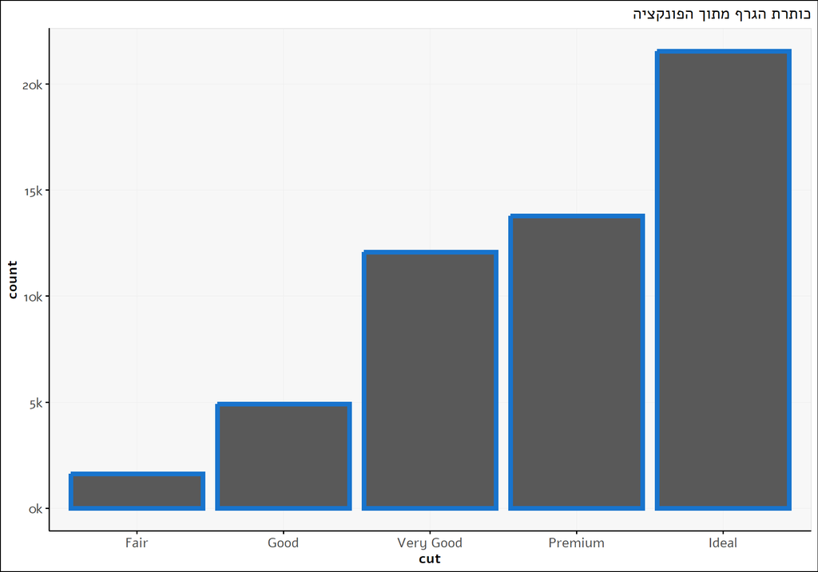

this is a caption for the figure

```r
p1 <- ggplot(data = diamonds) +
  geom_bar(mapping = aes(x = cut), color = "dodgerblue3",size =2) +
  scale_y_continuous(labels = scales::label_number(accuracy = 1, scale = 0.001, suffix = "k")) +
  labs(title = "כותרת הגרף מתוך הפונקציה")
p1
```

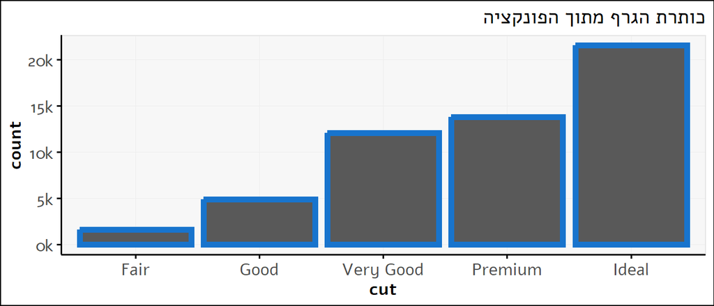

```r
p1
```

for the recent (work in progress) ggplot book :  
https://ggplot2-book.org/

## 3.3 noteable chunk options

- **eval** : (TRUE; logical or numeric) Whether to evaluate the code chunk. It can also be a numeric vector to choose which R expression(s) to evaluate, e.g., eval = c(1, 3, 4) will evaluate the first, third, and fourth expressions, and eval = -(4:5) will evaluate all expressions except the fourth and fifth.
- **echo** : (TRUE; logical or numeric) Whether to display the source code in the output document. can take specifics like in the eval example
- **cache** : (FALSE; logical) Whether to cache a code chunk. When evaluating code chunks for the second time, the cached chunks are skipped (unless they have been modified),
- **out.width,out.height**: (NULL; character) Width and height of the plot in the output document, which can be different with its physical fig.width and fig.height, i.e., plots can be scaled in the output document.
- **message, warning**: (TRUE; logical) Whether to preserve warnings or messages in the output. If FALSE, all warnings will be printed in the console instead of the output document. ( can also take numeric values as indices to select a subset of warnings to include in the output)
- **error** :(FALSE; logical) R will stop on error when running the code chunks.Sometimes you may want to show errors on purpose. If you want to show the errors without stopping R, you may use the chunk option error = TRUE

for full list of knitr option go to: https://yihui.org/knitr/options/  
the cookbook is usfull as well : https://bookdown.org/yihui/rmarkdown-cookbook/chunk-options.html

# 4 links to sources

[get started page on RDtudio](https://rmarkdown.rstudio.com/lesson-1.html)  
[The Definitive Guide](https://bookdown.org/yihui/rmarkdown/)  
[cook book](https://bookdown.org/yihui/rmarkdown-cookbook/)  
[markdown reference guide](https://rstudio.com/wp-content/uploads/2015/03/rmarkdown-reference.pdf)  
[cheat sheet](https://www.rstudio.org/links/r_markdown_cheat_sheet)